# EDA - White Wine (PEDRO BARBOSA DE OLIVEIRA FILHO)

# Visão Geral

O conjunto de dados em estudo contém 4.898 vinhos brancos com 11 variáveis de propriedades químicas do vinho. Ao menos 3 especialistas em vinhos avaliaram cada vinho, fornecendo uma nota entre 0 (muito ruim) e 10 (muito excelente). Este [arquivo texto](https://s3.amazonaws.com/udacity-hosted-downloads/ud651/wineQualityInfo.txt) descreve as variáveis e como os dados foram coletados.

# Questão Guia

Quais propriedades químicas influenciam a qualidade dos vinhos brancos?

# Seção de Gráficos Univariados

Um resumo das 12 variáveis presentes no conjunto de dados é apresentado abaixo. Cada uma das variáveis será explorada separademente nesta seção.

```
## 'data.frame':    4898 obs. of  13 variables:
##  $ X                   : int  1 2 3 4 5 6 7 8 9 10 ...
##  $ fixed.acidity       : num  7 6.3 8.1 7.2 7.2 8.1 6.2 7 6.3 8.1 ...
##  $ volatile.acidity    : num  0.27 0.3 0.28 0.23 0.23 0.28 0.32 0.27 0.3 0.22 ...
##  $ citric.acid         : num  0.36 0.34 0.4 0.32 0.32 0.4 0.16 0.36 0.34 0.43 ...
##  $ residual.sugar      : num  20.7 1.6 6.9 8.5 8.5 6.9 7 20.7 1.6 1.5 ...
##  $ chlorides           : num  0.045 0.049 0.05 0.058 0.058 0.05 0.045 0.045 0.049 0.044 ...
##  $ free.sulfur.dioxide : num  45 14 30 47 47 30 30 45 14 28 ...
##  $ total.sulfur.dioxide: num  170 132 97 186 186 97 136 170 132 129 ...
##  $ density             : num  1.001 0.994 0.995 0.996 0.996 ...
##  $ pH                  : num  3 3.3 3.26 3.19 3.19 3.26 3.18 3 3.3 3.22 ...
##  $ sulphates           : num  0.45 0.49 0.44 0.4 0.4 0.44 0.47 0.45 0.49 0.45 ...
##  $ alcohol             : num  8.8 9.5 10.1 9.9 9.9 10.1 9.6 8.8 9.5 11 ...
##  $ quality             : int  6 6 6 6 6 6 6 6 6 6 ...
```

```
##        X        fixed.acidity    volatile.acidity  citric.acid
##  Min.   :   1   Min.   : 3.800   Min.   :0.0800   Min.   :0.0000
##  1st Qu.:1225   1st Qu.: 6.300   1st Qu.:0.2100   1st Qu.:0.2700
##  Median :2450   Median : 6.800   Median :0.2600   Median :0.3200
##  Mean   :2450   Mean   : 6.855   Mean   :0.2782   Mean   :0.3342
##  3rd Qu.:3674   3rd Qu.: 7.300   3rd Qu.:0.3200   3rd Qu.:0.3900
##  Max.   :4898   Max.   :14.200   Max.   :1.1000   Max.   :1.6600
##  residual.sugar     chlorides       free.sulfur.dioxide
##  Min.   : 0.600   Min.   :0.00900   Min.   :  2.00
##  1st Qu.: 1.700   1st Qu.:0.03600   1st Qu.: 23.00
##  Median : 5.200   Median :0.04300   Median : 34.00
##  Mean   : 6.391   Mean   :0.04577   Mean   : 35.31
##  3rd Qu.: 9.900   3rd Qu.:0.05000   3rd Qu.: 46.00
##  Max.   :65.800   Max.   :0.34600   Max.   :289.00
##  total.sulfur.dioxide    density             pH          sulphates
##  Min.   :  9.0        Min.   :0.9871   Min.   :2.720   Min.   :0.2200
##  1st Qu.:108.0        1st Qu.:0.9917   1st Qu.:3.090   1st Qu.:0.4100
##  Median :134.0        Median :0.9937   Median :3.180   Median :0.4700
##  Mean   :138.4        Mean   :0.9940   Mean   :3.188   Mean   :0.4898
##  3rd Qu.:167.0        3rd Qu.:0.9961   3rd Qu.:3.280   3rd Qu.:0.5500
##  Max.   :440.0        Max.   :1.0390   Max.   :3.820   Max.   :1.0800
##     alcohol         quality
##  Min.   : 8.00   Min.   :3.000
##  1st Qu.: 9.50   1st Qu.:5.000
##  Median :10.40   Median :6.000
##  Mean   :10.51   Mean   :5.878
##  3rd Qu.:11.40   3rd Qu.:6.000
##  Max.   :14.20   Max.   :9.000
```

Nota-se que nenhuma das variáveis apresenta NA’s.

```r
colSums(is.na(white_wine))
```

```
##                    X        fixed.acidity     volatile.acidity
##                    0                    0                    0
##          citric.acid       residual.sugar            chlorides
##                    0                    0                    0
##  free.sulfur.dioxide total.sulfur.dioxide              density
##                    0                    0                    0
##                   pH            sulphates              alcohol
##                    0                    0                    0
##              quality
##                    0
```

### Acidez Fixa - fixed acidity (tartaric acid - g / dm^3)

Trata-se da maioria dos ácidos envolvidos com o vinho ou fixos ou não voláteis (não se evaporam prontamente).

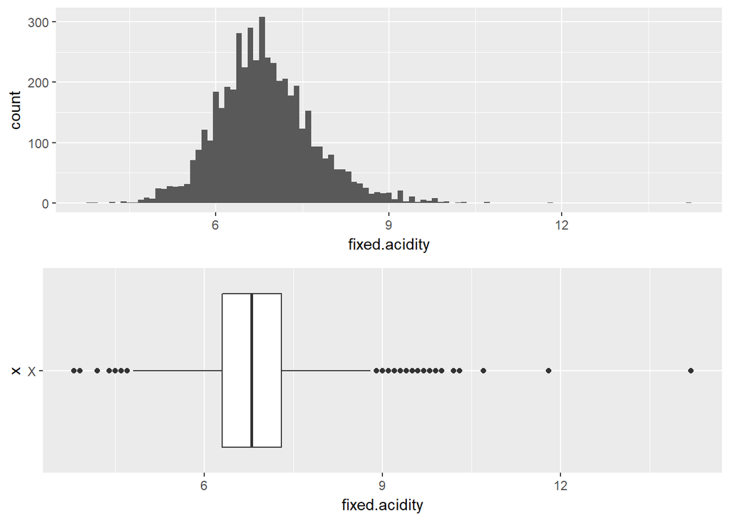

```
##    Min. 1st Qu.  Median    Mean 3rd Qu.    Max.
##   3.800   6.300   6.800   6.855   7.300  14.200
```

Nota-se que a maioria dos vinhos apresnetam uma acidez fixa entre 6.3 e 7.3 g/dm^3. Também é possível perceber a presença de outliers.

### Acidez Volátil - volatile acidity (acetic acid - g / dm^3)

Trata-se da quantidade de ácido acético no vinho, que em altíssimos níveis pode levar a um gosto desagradável de vinagre.

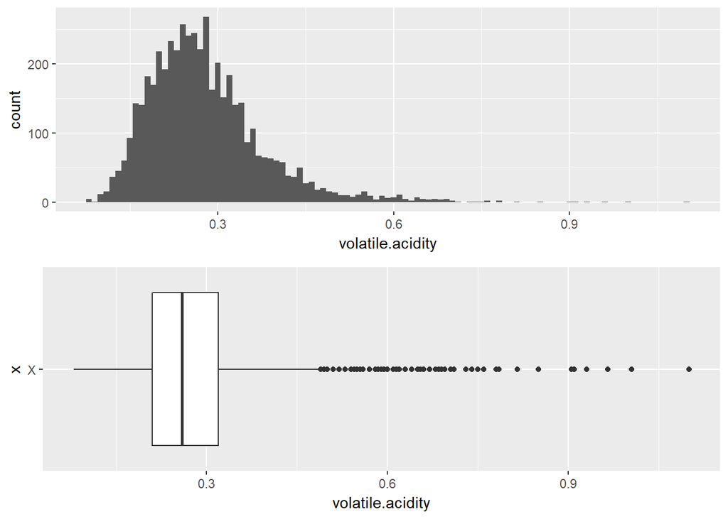

```
##    Min. 1st Qu.  Median    Mean 3rd Qu.    Max.
##  0.0800  0.2100  0.2600  0.2782  0.3200  1.1000
```

Nota-se que a maioria dos vinhos apresnetam uma acidez volátil entre 0.21 e 0.32 g/dm^3. Também é possível perceber um crescimento à direita da cauda da distribuição. O código abaixo mostra a existência de 186 outliers à direita da distribuição.

```r
# Valor limite do bigode superior do box plot
va_upper_wisker <- quantile(white_wine$volatile.acidity, 0.75) + 1.5 * IQR(white_wine$volatile.acidity)

# Número de outliers à direita da distribuição
table(white_wine$volatile.acidity > va_upper_wisker)
```

```
##
## FALSE  TRUE
##  4712   186
```

Pode-se utilizar a escala logarítmica de base 10 para aproximar a distribuição dos dados de acidez volátil de um formato normal.

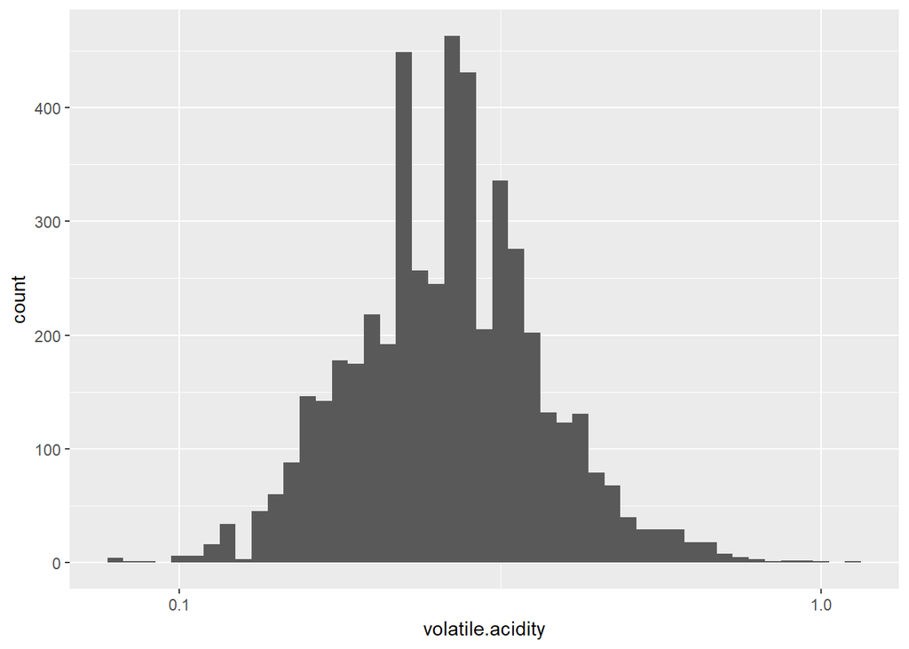

Nota-se que utilização da escala logarítmica reduz o tamanho da cauda à direita.

### Ácido Cítrico - citric acid (g / dm^3)

Encontrado em pequenas quantidades, o ácido cítrico pode adicionar frescor e sabor aos vinhos.

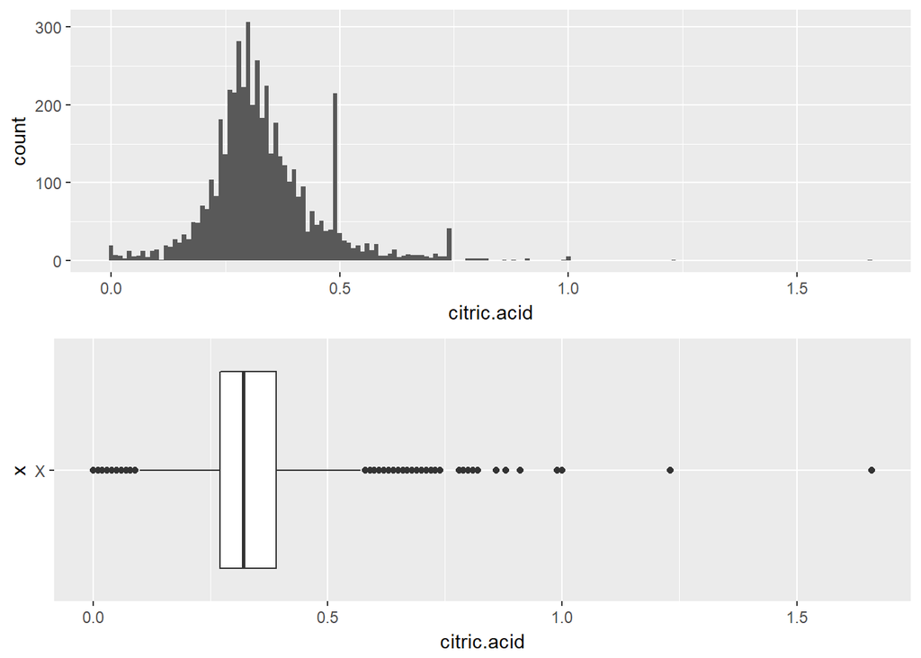

```
##    Min. 1st Qu.  Median    Mean 3rd Qu.    Max.
##  0.0000  0.2700  0.3200  0.3342  0.3900  1.6600
```

Nota-se que a maioria dos vinhos apresentam uma concentração de ácido cítrico entre 0.27 e 0.39 g/dm^3. Também é possível perceber mais de 200 vinhos apresentando uma concentração de ácido cítrico póxima a 0.50 g/dm^3.

O código abaixo mostra que 185 vinhos brancos apresentaram elevada concentração de ácido cítrico e foram considerados outliers. Também há indicação de 85 vinhos com baixas concentrações de ácido cítrico.

```r
# Valor limite do bigode superior do box plot
ca_upper_wisker <- quantile(white_wine$citric.acid, 0.75) + 1.5 * IQR(white_wine$citric.acid)

# # Valor limite do bigode inferior do box plot
ca_lower_wisker <- quantile(white_wine$citric.acid, 0.25) - 1.5 * IQR(white_wine$citric.acid)

# Número de outliers à direita da distribuição
table(white_wine$citric.acid > ca_upper_wisker)
```

```
##
## FALSE  TRUE
##  4713   185
```

```r
# Número de outliers à esquerda da distribuição
table(white_wine$citric.acid < ca_lower_wisker)
```

```
##
## FALSE  TRUE
##  4813    85
```

### Açúcar Residual - residual sugar (g / dm^3)

Trata-se da quantidade de açúcar restante após a o fim da fermentação. É raro encontrar vinhos com menos de 1 g/L sendo os vinhos com mais de 45 g/L considerados doces.

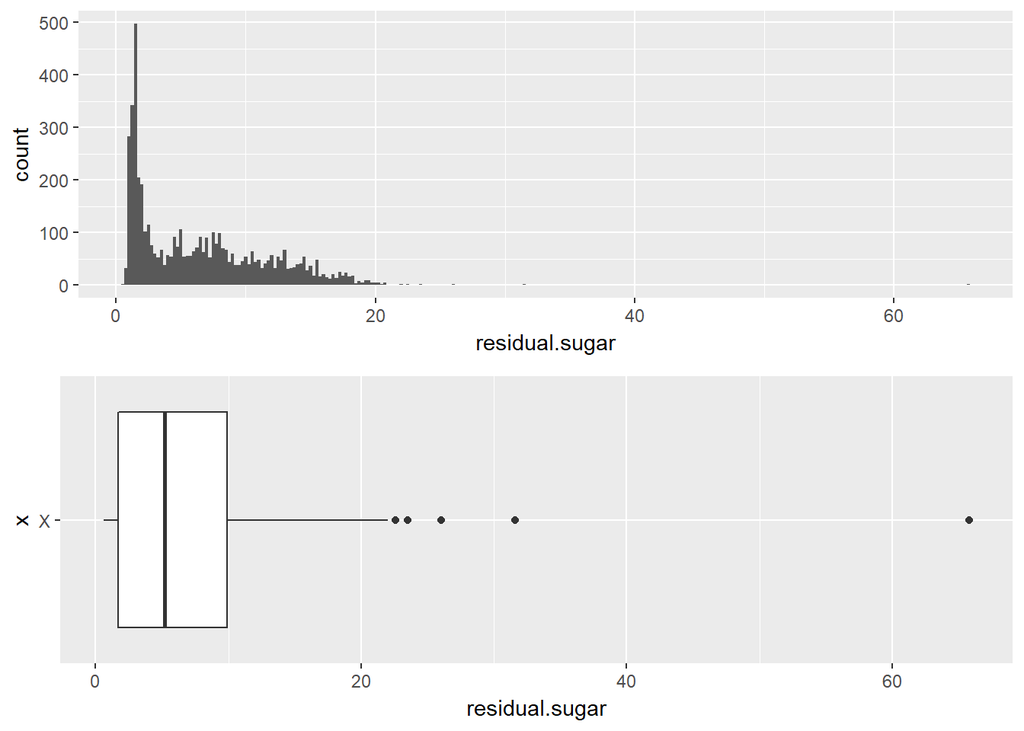

```
##    Min. 1st Qu.  Median    Mean 3rd Qu.    Max.
##   0.600   1.700   5.200   6.391   9.900  65.800
```

Nota-se que a maioria dos vinhos apresentam concentração de acúcar residual entre 1.7 e 9.9 g/dm^3. O código abaixo mostra que apenas 77 vinhos brancos apresnetaram concentração de açúcar inferior a 1 g/L, enquanto apenas um vinho branco foi consederado doce (concentração maior que 45 g/L).

```r
# Vinhos com concentração de açúcar inferior a 1 g/L
table(white_wine$residual.sugar < 1)
```

```
##
## FALSE  TRUE
##  4821    77
```

```r
# Vinhos com concentração de açúcar superior a 45 g/L
table(white_wine$residual.sugar > 45)
```

```
##
## FALSE  TRUE
##  4897     1
```

Também é possível perceber que a distribuição apresenta uma cauda longa para a direita. Assim, podemos aplicar a escala logarítmica de base 10 para aproxiamar à distribuição da normal.

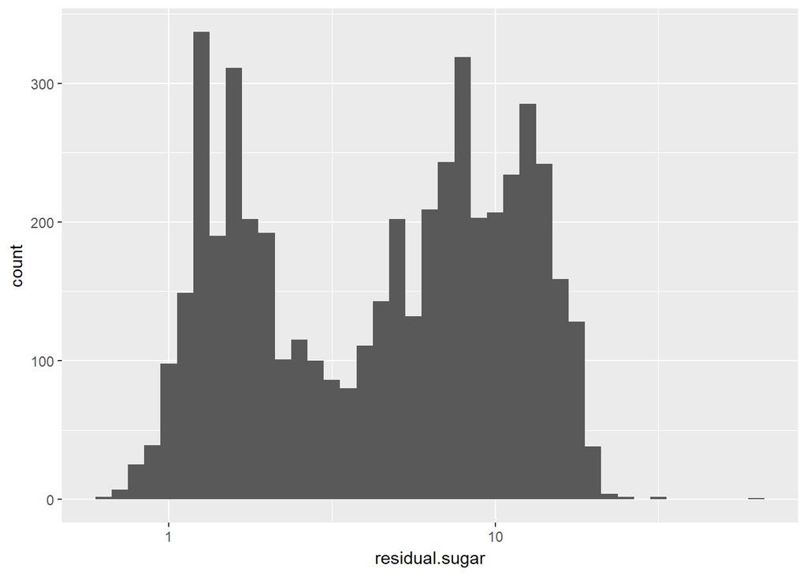

A escala logarítmica revelou uma característica bimodal da distribuição de concentração de açúcar residual. O código abaixo permite afirmar que existem 77 vinhos com concentração inferior a 1 g/dm^3 e apenas 1 vinho doce.

```r
# Vinhos com concentração de açúcar residual inferior a 1 g/dm^3
table(white_wine$residual.sugar<1)
```

```
##
## FALSE  TRUE
##  4821    77
```

```r
# Vinhos com concentração de açúcar residual superiro a 45 g/dm
table(white_wine$residual.sugar>45)
```

```
##
## FALSE  TRUE
##  4897     1
```

### Cloretos - chlorides (sodium chloride - g / dm^3)

Trata-se da quantidade de sal no vinho.

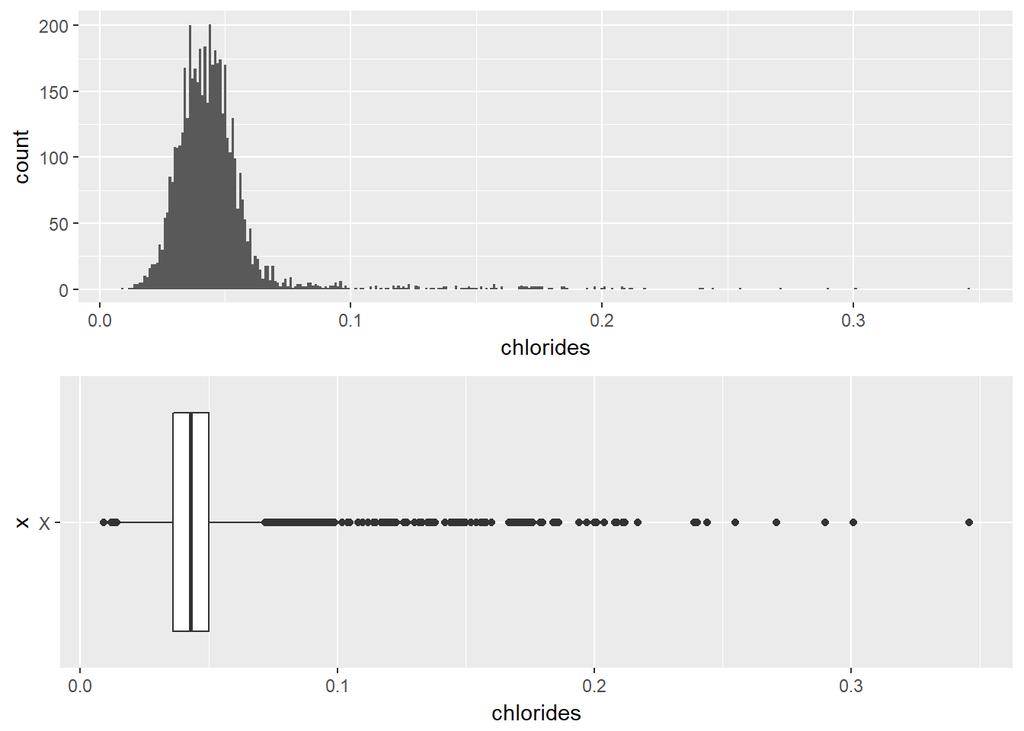

```
##    Min. 1st Qu.  Median    Mean 3rd Qu.    Max.
## 0.00900 0.03600 0.04300 0.04577 0.05000 0.34600
```

Nota-se que a maioria dos vinhos apresentam concentração de cloretos entre 0.036 e 0.050 g/dm^3. Também é possível perceber que existem alguns vinhos com concentrações de cloretos mais elevadas. Assim, podemos aplicar a escala logarítmica de base 10 para aproxiamar a distribuição da normal.

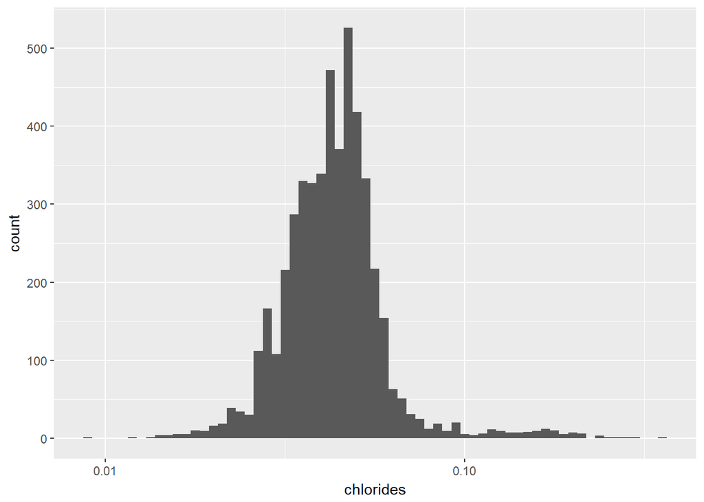

Nota-se que utilização da escala logarítmica aproxima reduz o tamanho da cauda à direita.

### Dióxido de Enxofre Livre - free sulfur dioxide (mg / dm^3)

A forma livre de SO2 existe em equilíbrio entre o SO2 molecular (como um gás dissolvido) e ion bisulfito. Trata-se de um agente que impede o crescimento microbiano e a oxidação do vinho.

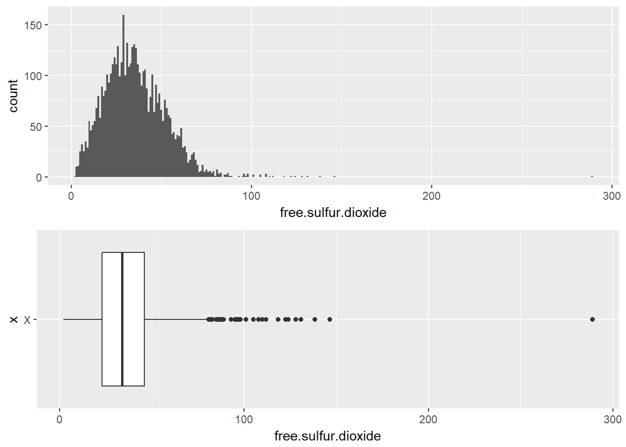

```
##    Min. 1st Qu.  Median    Mean 3rd Qu.    Max.
##    2.00   23.00   34.00   35.31   46.00  289.00
```

Nota-se que a maioria dos vinhos apresentam uma concentração de dióxido de enxofre livre entre 23 e 46 mg/dm^3. Nota-se a presença de outliers apenas à direita da distribuição. Aplicou-se a escala logarítmica com o objetivo de aproximar a distribuição da normal.

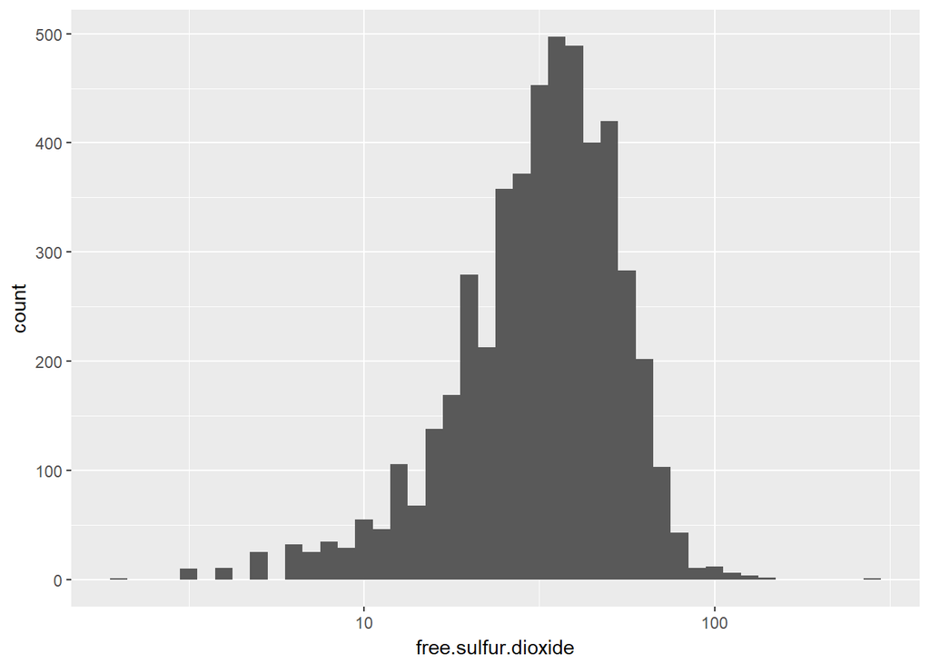

### Dióxido de Enxofre Total - total sulfur dioxide (mg / dm^3)

Quantidade de formas livres e ligadas de SO2. Em baixas concentrações, o SO2 é praticamete imperceptível no vinho. Entretando, concentrações de SO2 livre acima de 50 ppm são perceptíveis ao olfato e paladar.

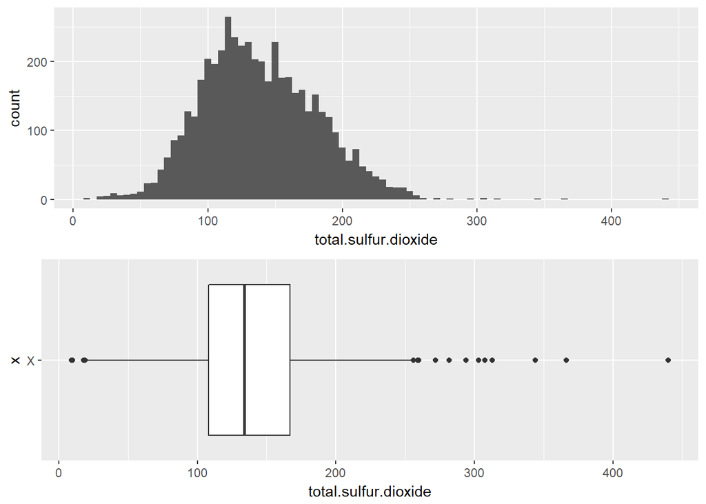

```
##    Min. 1st Qu.  Median    Mean 3rd Qu.    Max.
##     9.0   108.0   134.0   138.4   167.0   440.0
```

Nota-se que a maioria dos vinhos apresentam uma concentração total de dióxido de enxofre entre 108 e 167 mg/dm^3.

O código abaixo demostra que apenas 46 vinhos brancos analisados apresentam uma concentração de dióxido de enxofre total inferior a 50 mg/dm^3 (ppm).

```r
table(white_wine$total.sulfur.dioxide < 50)
```

```
##
## FALSE  TRUE
##  4852    46
```

### Densidade - density (g / cm^3)

A densidade é próxima a da água dependendo do percentual de teor de álcool e açúcar.

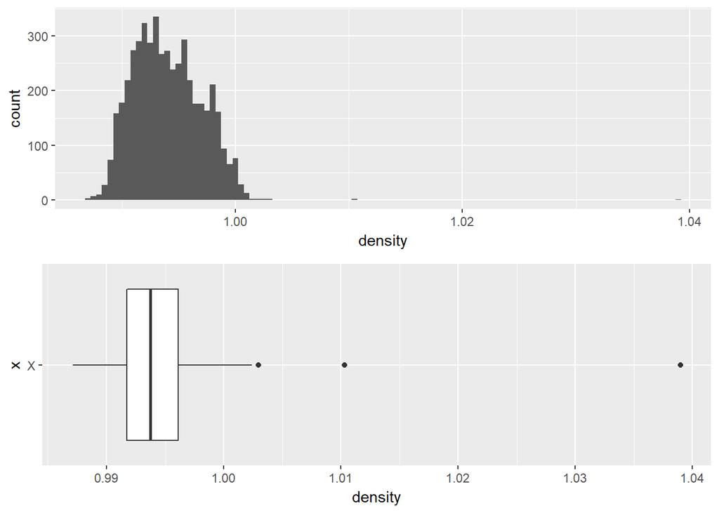

```
##    Min. 1st Qu.  Median    Mean 3rd Qu.    Max.
##  0.9871  0.9917  0.9937  0.9940  0.9961  1.0390
```

Nota-se que a maioria dos vinhos apresentam uma densidade entre 0.9917 e 0.9961 mg/cm^3. Ressalta-se a presença de poucos outliers.

### pH

Descreve o quão ácido ou básico está o vinho em uma escala de 0 (muito ácida) a 14 (muito básico). A maioria dos vinhos apresenta pH entre 3-4.

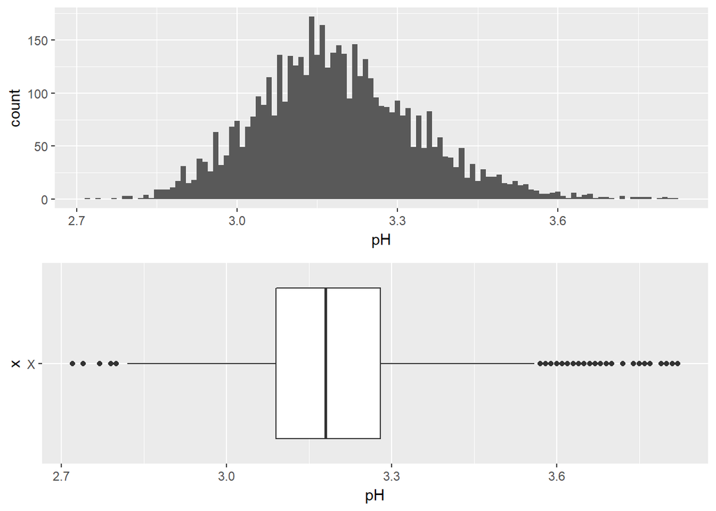

```
##    Min. 1st Qu.  Median    Mean 3rd Qu.    Max.
##   2.720   3.090   3.180   3.188   3.280   3.820
```

Nota-se que a maioria dos vinhos apresentam um pH entre 3.090 e 3.280.

### Sulfatos - sulphates (potassium sulphate - g / dm3)

Um aditivo que pode contribuir para os níveis de dióxido de enxofre (SO2), que atua como antimicrobiano e antioxidante.

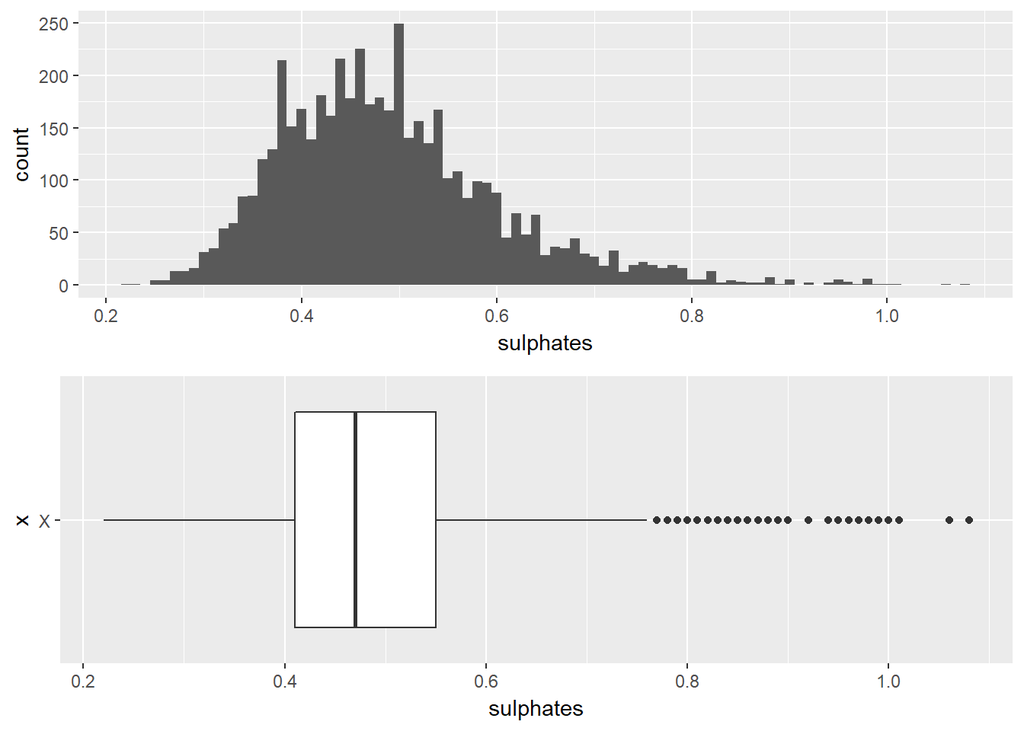

```
##    Min. 1st Qu.  Median    Mean 3rd Qu.    Max.
##  0.2200  0.4100  0.4700  0.4898  0.5500  1.0800
```

Nota-se que a maioria dos vinhos apresentam uma concentração de sulfatos entre 0.41 e 0.55 g/dm^3. Também é possível perceber que todos os outliers localizam-se à direita, alongando a cauda da distribuição. O gráfico abaixo utiliza a escala logarítmica para aproximar a distribuição à normal.

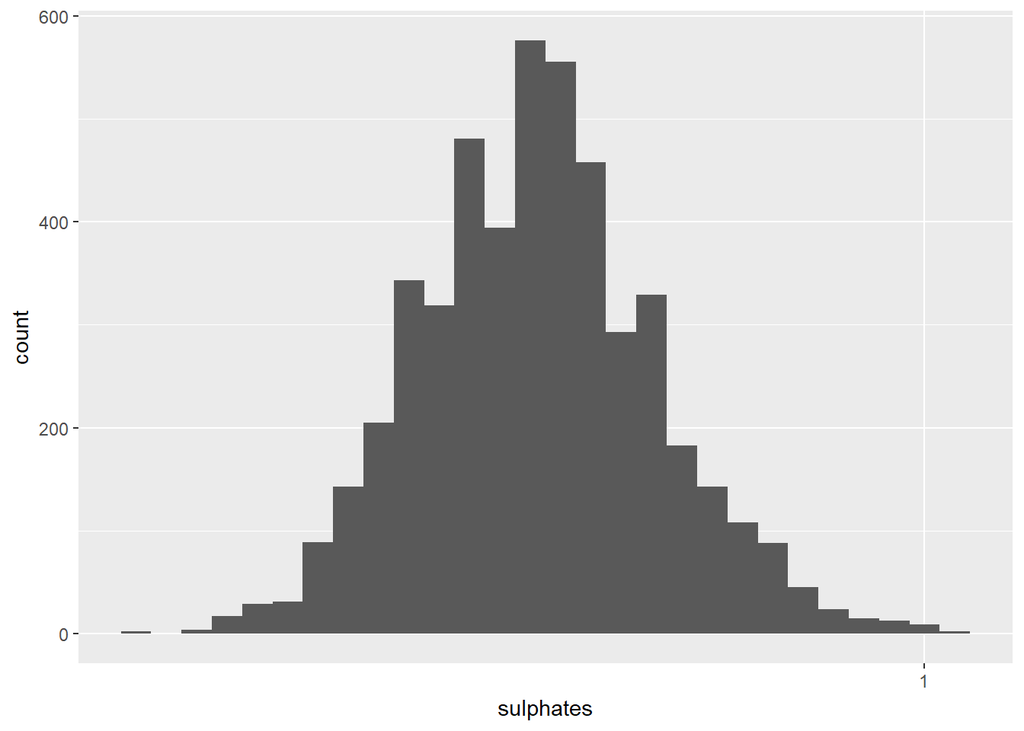

### Álcool - alcohol (% by volume)

O percentual de conteúdo alcoólico do vinho.

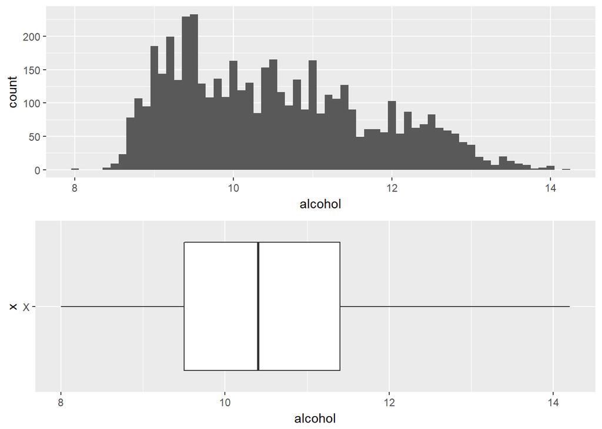

```
##    Min. 1st Qu.  Median    Mean 3rd Qu.    Max.
##    8.00    9.50   10.40   10.51   11.40   14.20
```

Nota-se que a maioria dos vinhos apresentam um percentual de álcool entre 9.50 e 11.40. Ressalta-se a ausência de outliers para a distribuição da concentração de álcool nos vinhos brancos. A escala logarítmica foi utilizada no gráfico abaixo com o objetivo de aproximar a distribuição à normal

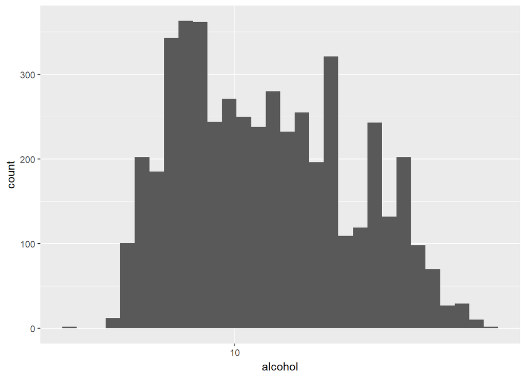

### Qualidade - quality (score between 0 and 10)

A variável de saída.

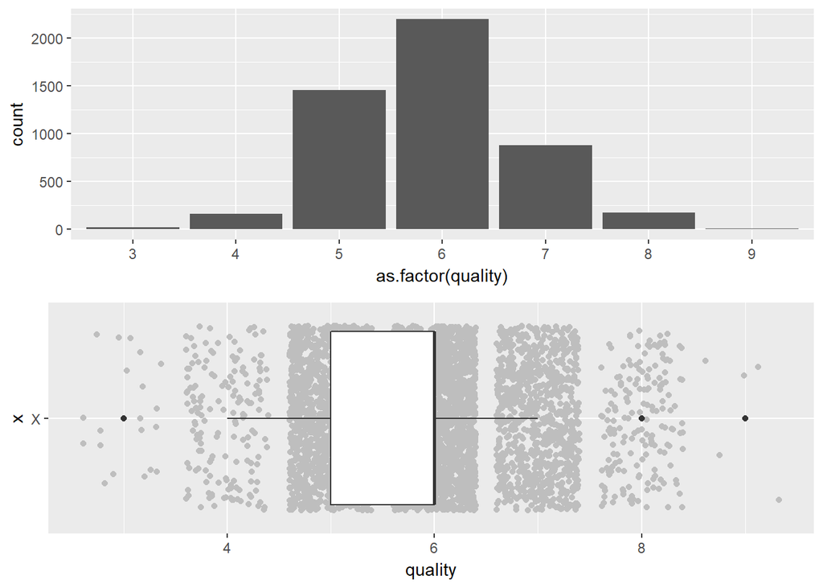

```
##    Min. 1st Qu.  Median    Mean 3rd Qu.    Max.
##   3.000   5.000   6.000   5.878   6.000   9.000
```

```
## # A tibble: 7 × 2
##   `as.factor(quality)` total
##                 <fctr> <int>
## 1                    3    20
## 2                    4   163
## 3                    5  1457
## 4                    6  2198
## 5                    7   880
## 6                    8   175
## 7                    9     5
```

Segundo os gráficos acima e a tabela acima, mais de 2000 vinhos apresentaram qualidade 6. Entretanto, tivemos uma pequena quantidade de vinhos com qualidade elevada (8 e 9) e reduzida (3 e 4). Vinhos brancos com qualidade 3, 8 e 9 aparecem como outliers no box plot.

Devido ao interesse em identificar quais propriedades químicas apresentam maior influência na qualidade do vinho branco, adicionou-se uma nova variável ao conjunto de dados conforme código abaixo:

```r
white_wine <- white_wine %>%
  mutate(new_quality = cut(quality, breaks = c(2,4,7,10),
                           labels = c("Ruim", "Comum", "Bom")))

str(white_wine$new_quality)
```

```
##  Factor w/ 3 levels "Ruim","Comum",..: 2 2 2 2 2 2 2 2 2 2 ...
```

```r
summary(white_wine$new_quality)
```

```
##  Ruim Comum   Bom
##   183  4535   180
```

A variável **new_quality** agrupa os vinhos brancos em 3 classificações de qualidade:

# Análise Univariada

### Quais são os principais atributos de interesse deste conjunto de dados?

Avaliando cada uma das 11 variáveis de entrada individualmente, não foi possível identificar quais as propriedades químicas apresentam maior influência na qualidade do vinho branco. Entretanto, a partir da leitura do [arquivo texto que descreve as variáveis](https://s3.amazonaws.com/udacity-hosted-downloads/ud651/wineQualityInfo.txt), acredita-se que os principais atributos de interesse sejam:

- Acidez volatel
- Ácido cítrico
- Açúcar residual
- Dióxido de enxofre total

Na **Seção de Gráficos Bivariados** será investigado o relacionamento entre as propriedades químicas e a nota de qualidade dos vinhos atribuída pelos especialistas.

### Quais outros atributos você acha que podem lhe auxiliar na investigação destes atributos de interesse?

Acredito que o teor de álcool no vinho branco pode ser uma variável influente na qualidade do vinho branco.

### Você criou novas variáveis a partir dos atributos existentes no conjunto de dados?

A variável **new_quality** foi criada com o objetivo de fundamentar as próximas análises. Trata-se de uma classificação das notas de qualidade entre Ruim, Comum e Bom.

### Dos atributos investigados, distribuições incomuns foram encontradas? Você aplicou operações nos dados para limpá-los, ajustá-los ou mudar a forma dos dados? Se sim, por quê?

A concentração de **açúcar residual** apresentou uma distribuição com uma longa cauda à direita. A aplicação da escala logarítmica na distribuição de **açúcar residual** revelou um comportamento bimodal.

# Seção de Gráficos Bivariados

Para o melhor entendimento sobre a influência das propriedades químicas na qualidade dos vinhos, serão avaliadas as correlações entre as propriedades físicas e a nota de qualidade. O gráfico abaixo apresenta a matriz de correlação das variáveis.

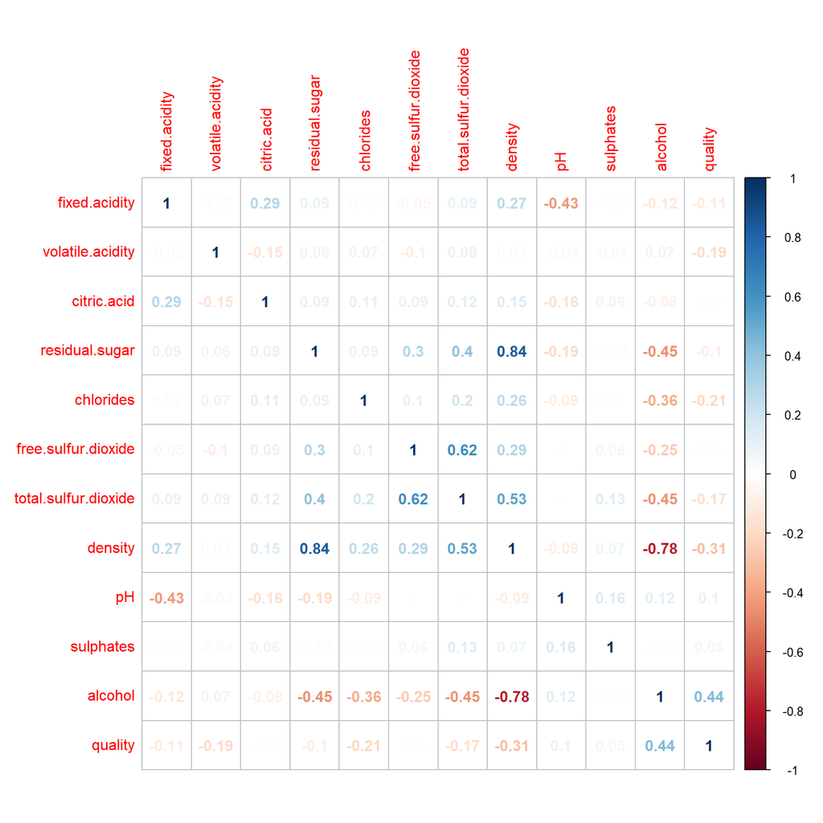

As propriedades químicas mais fortemente correlacionadas com a qualidade dos vinhos brancos estão listadas abaixo:

- Acidez volátil (-0.194723)
- Cloretos (-0.2099344)
- Dióxido de enxofre total (-0.1747372)
- Densidade (-0.3071233)
- Porcentagem de álcool (0.4355747)

No decorrer desta seção de gráficos bivarados será dado ênfase aos atributos de interesse listados na análise univariada e às propriedades químicas mais fortemete correlacionadas com a qualidade dos vinhos brancos:

- Acidez volatel
- Ácido cítrico
- Açúcar residual
- Dióxido de enxofre total
- Cloretos
- Densidade
- Porcentagem de álcool

#### Acidez Volátil Vs. Qualidade

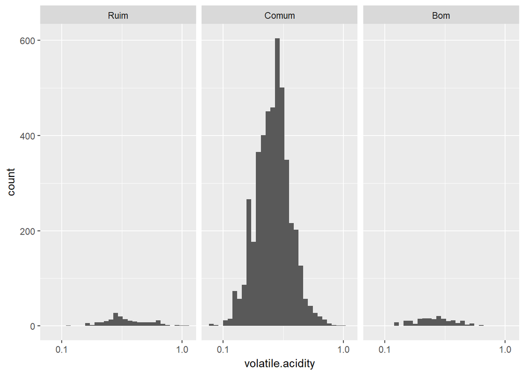

Nota-se que o gráfico acima não permite a identificação das distribuições de qualidade *Ruim* e *Bom*. A distribuição da concentração de **acidez volátil** para os vinhos de qualidade *Comum* apresenta comportamento semelhante à distribuição normal.

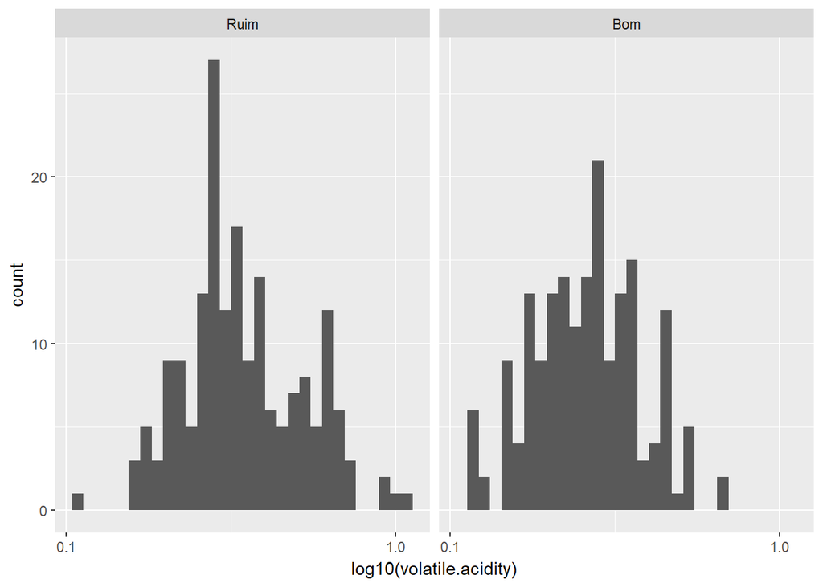

Os histogramas acima apresentam o comporta da distribuição da concentração de **acidez volátil** para os vinhos de qualidade *Ruim* e *Bom*. Utilizou-se a escala logarítmica para auxiliar na visualização da distribuição. Os histograma não permitem observar diferença significativa entre na concentração de **acidez volátil** para os vinhos classificados como *Bom* e *Ruim*.

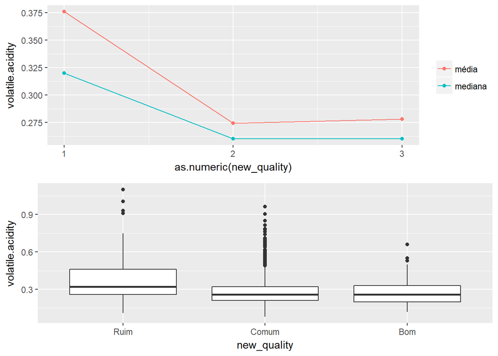

```
## white_wine$new_quality: Ruim
##    Min. 1st Qu.  Median    Mean 3rd Qu.    Max.
##   0.110   0.260   0.320   0.376   0.460   1.100
## --------------------------------------------------------
## white_wine$new_quality: Comum
##    Min. 1st Qu.  Median    Mean 3rd Qu.    Max.
##  0.0800  0.2100  0.2600  0.2743  0.3200  0.9650
## --------------------------------------------------------
## white_wine$new_quality: Bom
##    Min. 1st Qu.  Median    Mean 3rd Qu.    Max.
##   0.120   0.200   0.260   0.278   0.330   0.660
```

Os gráficos acima apresentam: (1) a variação das estatísticas média e mediana para a concentração de **acidez volátil**, e (2) os boxplots que ilustram a presença de outliers entre as classificações de qualidade. Não foi observada diferença significativa entre as concentrações de **acidez volátil** para os vinhos *Comum* e *Bom* (apresentam o mesmo valor mediano). Entretanto, os vinhos brancos classificados como *Ruim* apresentaram maior maior concentração de **acidez volátil**.

#### Ácido Cítrico Vs. Qualidade

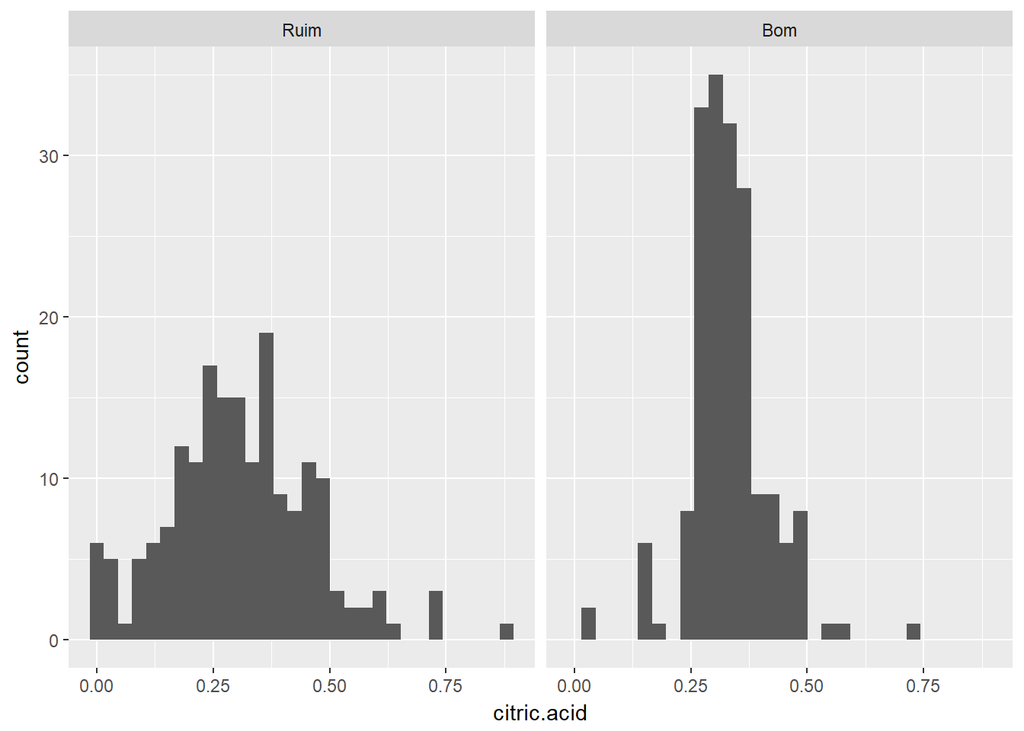

Os histogramas acima permitem avaliar o formato da distribuição.

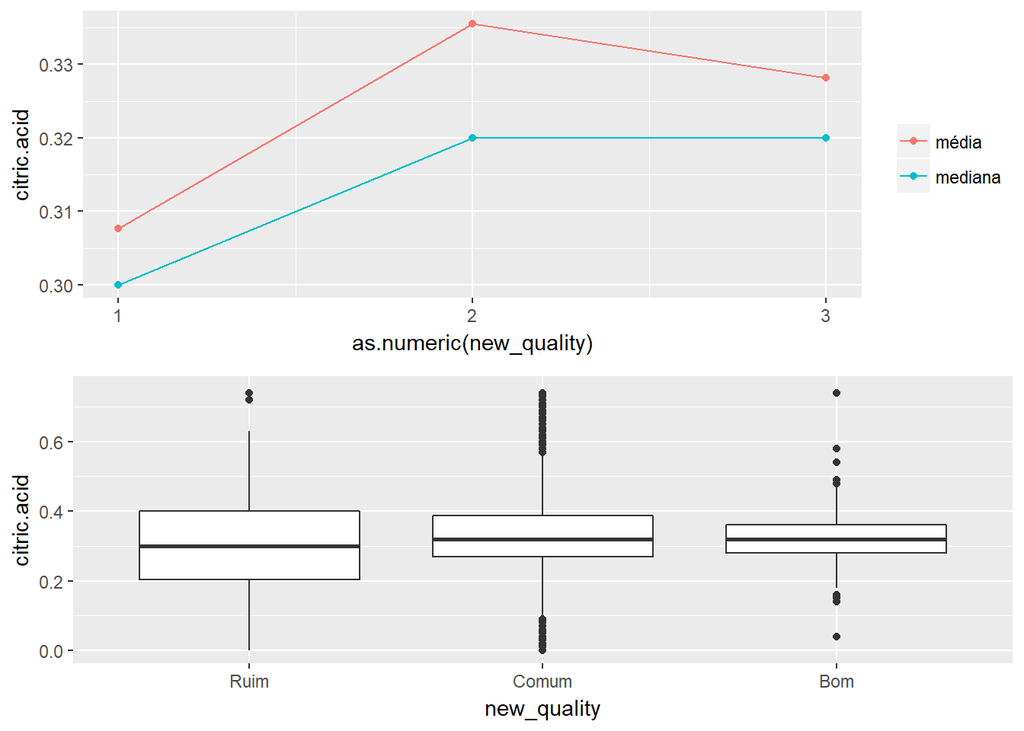

```
## white_wine$new_quality: Ruim
##    Min. 1st Qu.  Median    Mean 3rd Qu.    Max.
##  0.0000  0.2050  0.3000  0.3077  0.4000  0.8800
## --------------------------------------------------------
## white_wine$new_quality: Comum
##    Min. 1st Qu.  Median    Mean 3rd Qu.    Max.
##  0.0000  0.2700  0.3200  0.3355  0.3900  1.6600
## --------------------------------------------------------
## white_wine$new_quality: Bom
##    Min. 1st Qu.  Median    Mean 3rd Qu.    Max.
##  0.0400  0.2800  0.3200  0.3282  0.3600  0.7400
```

Observando os gráficos e tabela acima nota-se que a estatística mediana apresenta o mesmo valor para as concentrações de **ácido cítrico** de vinhos brancos classificados como *Comumn* e *Bom*.

#### Açúcar Residual Vs. Qualidade

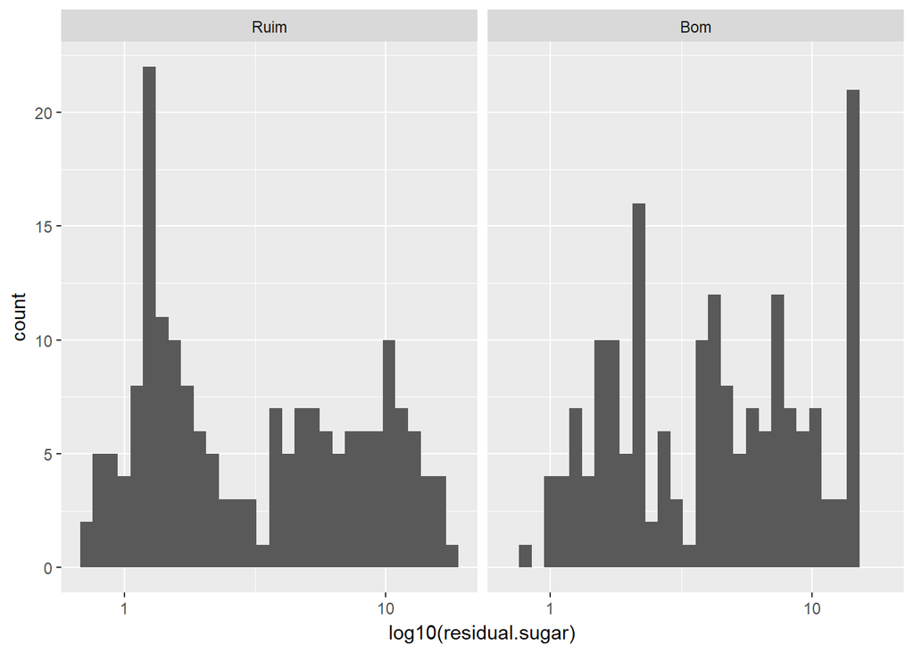

É possível verificar o comportamento bimodal da concentração de **açúcar residual** para os vinhos brancos classificados como *Ruim* e *Bom*.

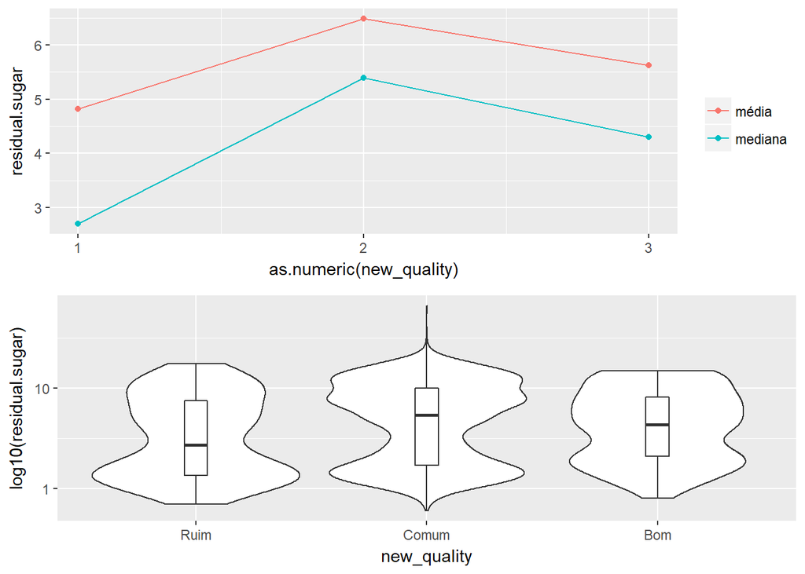

```
## white_wine$new_quality: Ruim
##    Min. 1st Qu.  Median    Mean 3rd Qu.    Max.
##   0.700   1.350   2.700   4.821   7.500  17.550
## --------------------------------------------------------
## white_wine$new_quality: Comum
##    Min. 1st Qu.  Median    Mean 3rd Qu.    Max.
##   0.600   1.700   5.400   6.485  10.000  65.800
## --------------------------------------------------------
## white_wine$new_quality: Bom
##    Min. 1st Qu.  Median    Mean 3rd Qu.    Max.
##   0.800   2.075   4.300   5.628   8.150  14.800
```

Utilizou-se o violin plot juntamente com o box plot para ressaltar a característica bimodal da distribuição verificada com a utilização da escala logarítmica.

#### Cloretos Vs. Qualidade

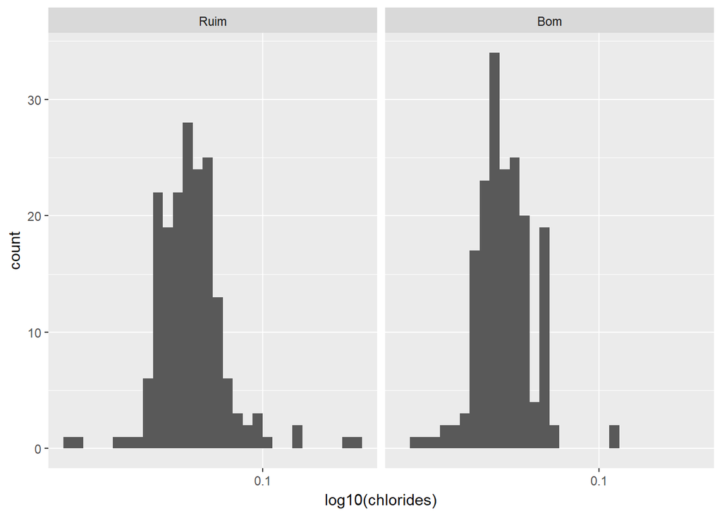

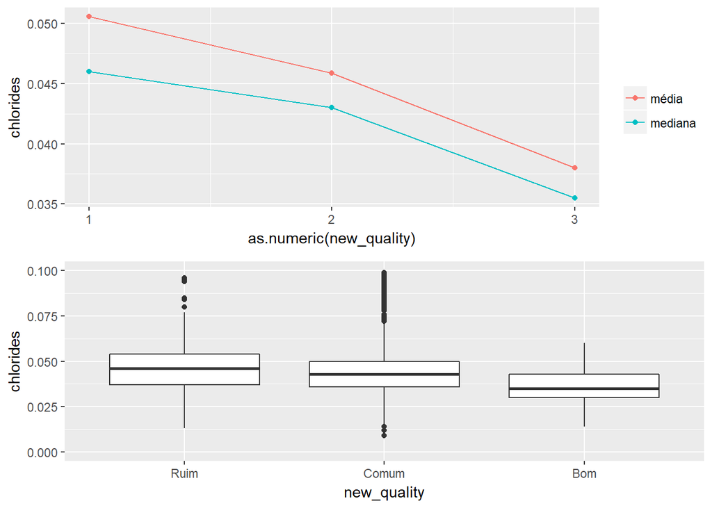

```
## white_wine$new_quality: Ruim
##    Min. 1st Qu.  Median    Mean 3rd Qu.    Max.
## 0.01300 0.03750 0.04600 0.05056 0.05400 0.29000
## --------------------------------------------------------
## white_wine$new_quality: Comum
##    Min. 1st Qu.  Median    Mean 3rd Qu.    Max.
## 0.00900 0.03600 0.04300 0.04589 0.05000 0.34600
## --------------------------------------------------------
## white_wine$new_quality: Bom
##    Min. 1st Qu.  Median    Mean 3rd Qu.    Max.
## 0.01400 0.03000 0.03550 0.03801 0.04400 0.12100
```

Observa-se uma leve tendência decrescente da concentração de **clorestos** para vinhos brancos de melhor qualidade.

#### Dióxido de Enxofre Total Vs. Qualidade

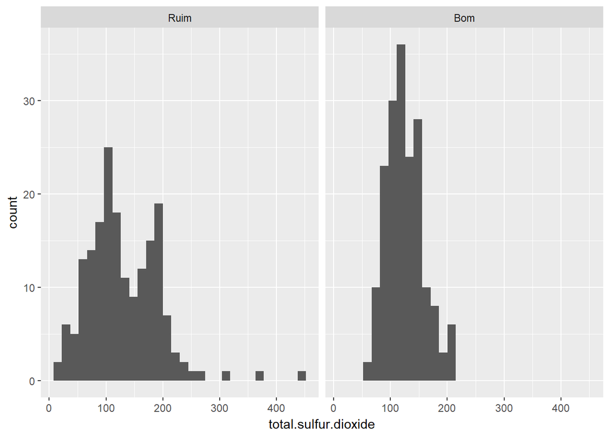

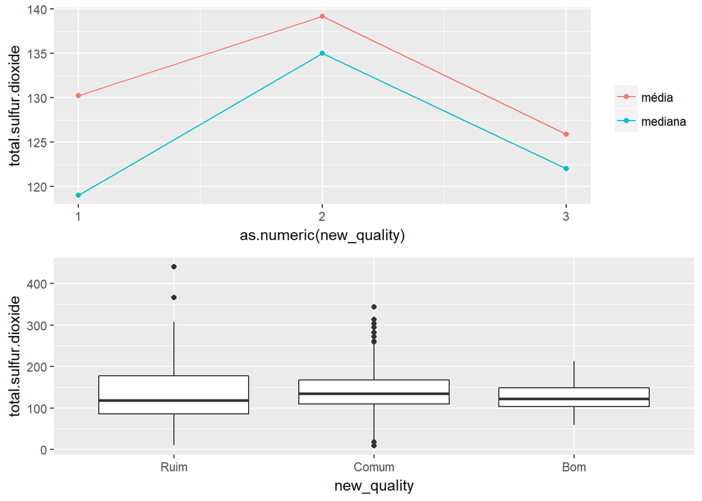

```
## white_wine$new_quality: Ruim
##    Min. 1st Qu.  Median    Mean 3rd Qu.    Max.
##    10.0    85.5   119.0   130.2   177.0   440.0
## --------------------------------------------------------
## white_wine$new_quality: Comum
##    Min. 1st Qu.  Median    Mean 3rd Qu.    Max.
##     9.0   109.0   135.0   139.2   168.0   344.0
## --------------------------------------------------------
## white_wine$new_quality: Bom
##    Min. 1st Qu.  Median    Mean 3rd Qu.    Max.
##    59.0   102.8   122.0   125.9   148.5   212.5
```

Observa-se que o comportamento das estatísticas média e mediana não são paralelos. O gráfico de linhas e pontos mostra que, vinhos com classificação *Ruim* possuem média superior, porém mediana inferior quando comparados aos vinhos de classificação *Boa*.

Segundo informações retiradas [deste arquivo texto](https://s3.amazonaws.com/udacity-hosted-downloads/ud651/wineQualityInfo.txt), a concentração de **dióxido de enxofre total** passa a ser perceptível ao olfato e paladar a partir de 50 ppm. Apenas 46 vinhos brancos apresentaram concentração de **dióxido de enxofre total** inferior a 50 ppm. O código abaixo mostra que nenhum dos 46 vinhos brancos com concentração de **dióxido de enxofre total** inferior a 50 ppm foi classificado como *Bom*.

```r
white_wine %>%
  filter(total.sulfur.dioxide < 50) %>%
  group_by(new_quality) %>%
  summarise(total = n())
```

```
## # A tibble: 2 × 2
##   new_quality total
##        <fctr> <int>
## 1        Ruim    10
## 2       Comum    36
```

#### Densidade Vs. Qualidade

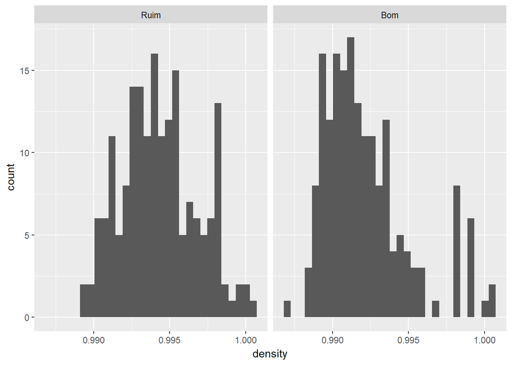

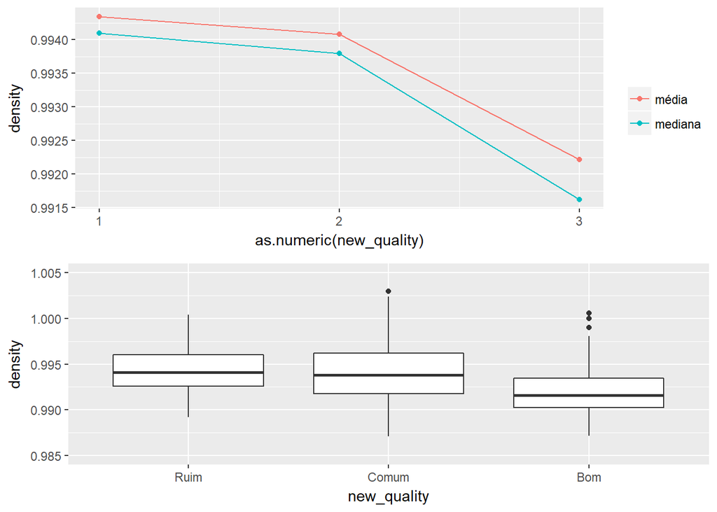

```
## white_wine$new_quality: Ruim
##    Min. 1st Qu.  Median    Mean 3rd Qu.    Max.
##  0.9892  0.9926  0.9941  0.9943  0.9960  1.0004
## --------------------------------------------------------
## white_wine$new_quality: Comum
##    Min. 1st Qu.  Median    Mean 3rd Qu.    Max.
##  0.9871  0.9918  0.9938  0.9941  0.9962  1.0390
## --------------------------------------------------------
## white_wine$new_quality: Bom
##    Min. 1st Qu.  Median    Mean 3rd Qu.    Max.
##  0.9871  0.9903  0.9916  0.9922  0.9935  1.0006
```

Observa-se que vinhos com **densidades** menores tendem a apesentar melhor qualidade.